# Looking at Traits

Going to look at some patterns in traits

```r
library(ggplot2)
library(data.table)


traits <- read.csv(here::here("Data","Traits","TraitCollectionFishNAtlanticNEPacificContShelf.csv"))
traits <- data.table(traits)
```

Subset to NA, and avg value by ocean

```r
#restrict to FAO 76, 77, 31, 21
traits_NA <- traits[FAO %in% c(67, 77, 31, 21)]

#ocean_LME_key
LME_ocean_key <- data.table("FAO" = c(67, 77, 31, 21), "ocean" = factor(c("pac","pac","atl","atl")))

#link by ocean
traits_NA_ocean <- traits_NA[LME_ocean_key, on = "FAO"]

#remove duplicates
traits.u <- unique(traits_NA_ocean[,.(ocean, taxon,tl, age.maturity, length.max, age.max)])

#avg value per FAO
traits.u[,tl_ocean := mean(tl, na.rm = T), .(taxon, ocean)][,age.maturity_ocean := mean(age.maturity, na.rm = T), .(taxon, ocean)][,age.max_ocean := mean(age.max, na.rm = T), .(taxon, ocean)][,length.max_ocean := mean(length.max, na.rm = T), .(taxon, ocean)]

#remove duplicates again
traits.u <- unique(traits.u[,.(ocean, taxon,tl_ocean, age.maturity_ocean, length.max_ocean, age.max_ocean)])
```

Interested in looking at max age, trophic level, and age of maturity

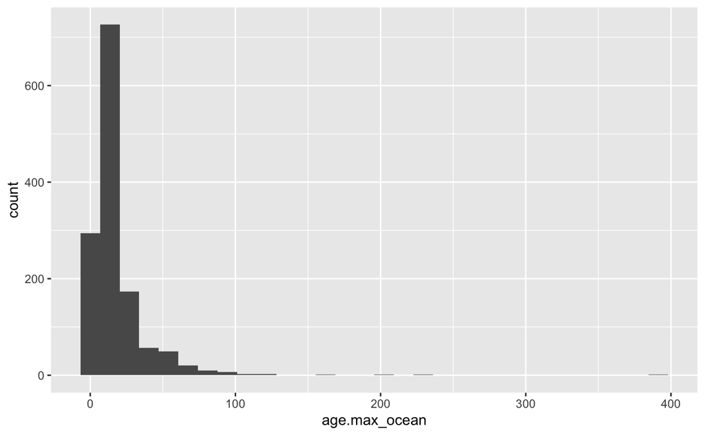

```r
ggplot(aes(x=age.max_ocean), data = traits.u) +
  geom_histogram()
```

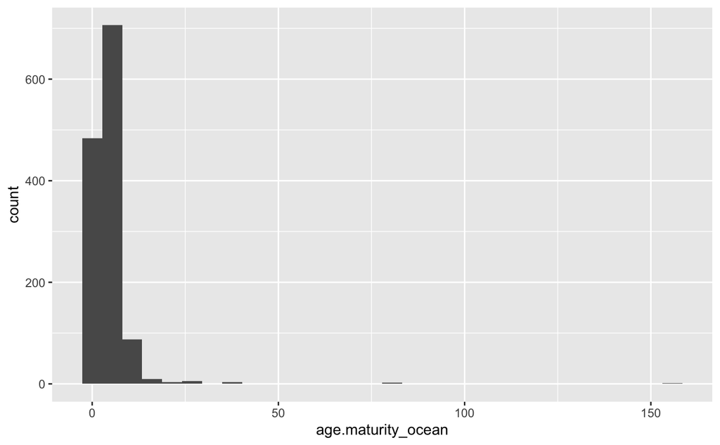

```r
ggplot(aes(x=age.maturity_ocean), data = traits.u) +
  geom_histogram()
```

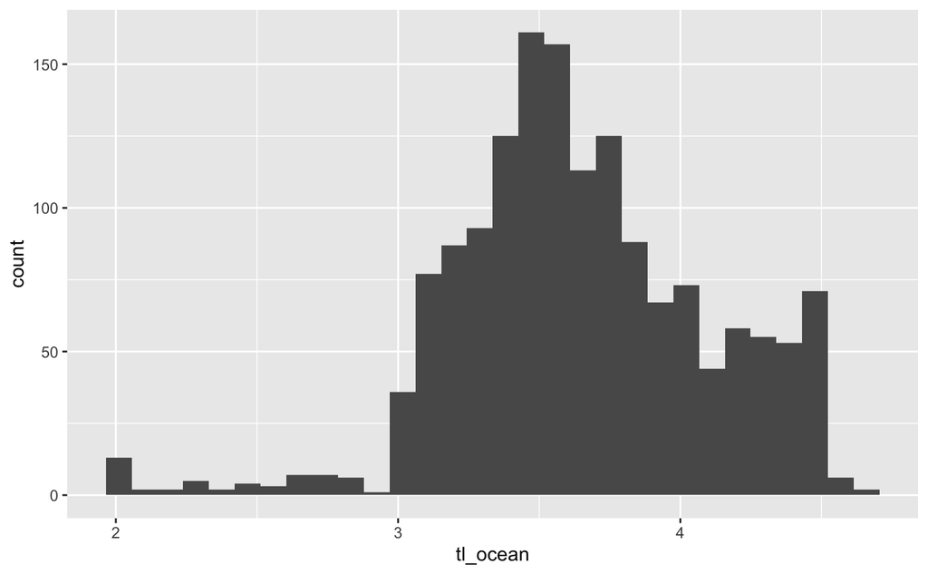

```r
ggplot(aes(x=tl_ocean), data = traits.u) +
  geom_histogram()
```

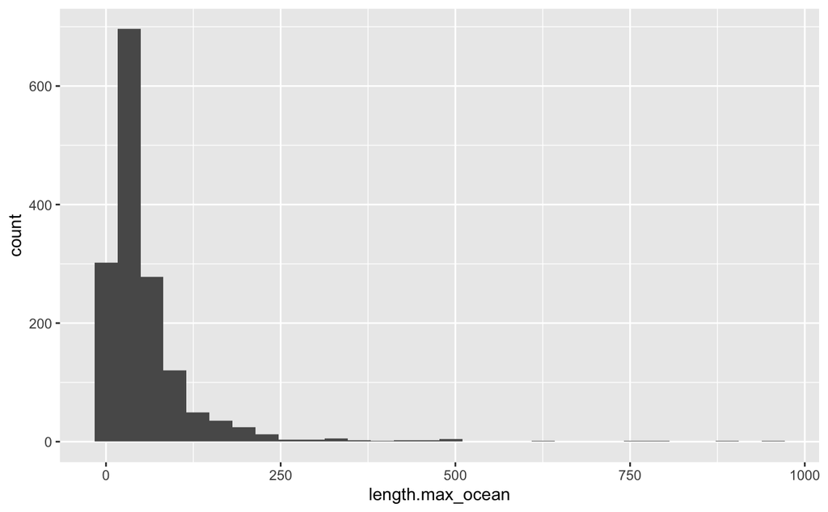

```r
ggplot(aes(x=length.max_ocean), data = traits.u) +
  geom_histogram()
```

```r
cor(na.omit(traits.u[,.(age.max_ocean, age.maturity_ocean, length.max_ocean, tl_ocean)]))
```

```
                   age.max_ocean age.maturity_ocean length.max_ocean  tl_ocean
age.max_ocean          1.0000000          0.6999808        0.3892358 0.1893111
age.maturity_ocean     0.6999808          1.0000000        0.4546983 0.1632310
length.max_ocean       0.3892358          0.4546983        1.0000000 0.3699567
tl_ocean               0.1893111          0.1632310        0.3699567 1.0000000
```

Let’s link species

First, let’s see if there are any name errors?

```r
spp_master_ztemp_seus_buoy <- readRDS(here::here("Data","Spp_master","spp_master_ztemp_seus_buoy.rds")) #load in observation data for arrivals and departures

#add ocean to this datatable
ocean_reg_key <- data.table(reg = unique(spp_master_ztemp_seus_buoy$reg), ocean = factor(c("pac","pac","atl","pac","atl","atl","atl","pac","atl")))

#merge
spp_master_ztemp_seus_buoy <- spp_master_ztemp_seus_buoy[ocean_reg_key, on = "reg"]

#list of spp from spp master ztemp
spp_master_spp <- data.frame(spp = unique(spp_master_ztemp_seus_buoy$spp), origin = "spp_master") #list of spp from spp_master df

traits_spp <- data.frame(spp = unique(traits.u$taxon), origin = "traits") #list of spp from traits df
spp_all <- rbind(spp_master_spp, traits_spp) #row bind together
spp_all$spp <- as.character(spp_all$spp) #make sure all are characters
spp_all.u <- spp_all[!duplicated(spp_all$spp),] #if duplicated, leave out, leaves only ones that were not duplicated
```

#Species to fix

species | location

Arctozenus risso | spp_master Arctozenus risso kroyeri | spp_master *Arctozenus risso in traits, so best to apply same to both Arctozenus and Artozenus risso kroyeri in spp_master

```r
row <- traits.u[taxon == "Arctozenus risso",]
row[,taxon := "Arctozenus risso kroyeri"]
traits.u <- rbind(traits.u, row)
```

Myoxocephalus scorpioides | spp_master Myoxocephalus scorpius | spp_master *yes, these are different!

Auxis rochei rochei | traits *ignore, not in our hauls

Diplecogaster bimaculata | traits Diplecogaster bimaculata bimaculata | traits *ignore, not in our hauls

Etrumeus teres | traits Etrumeus teres(sadina) | spp_master *change spp_master to Etrumeus teres

```r
spp_master_ztemp_seus_buoy[spp == "Etrumeus teres(sadina)", spp := "Etrumeus teres"]
```

Eualus gaimardii gaimardii | spp_master *ignore, not in trait database

Gasterosteus aculeatus | traits Gasterosteus aculeatus williamsoni | traits *ignore, not in our hauls

Lestidiops jayakari | traits Lestidiops jayakari jayakari | traits *ignore, not in our hauls

Liparis liparis liparis | traits *ignore, not in our hauls

Macroramphosus scolopax | traits Macrorhamphosus scolopax | spp_master *spelling error in spp_master, change to Macroramphosus scolopax

```r
spp_master_ztemp_seus_buoy[spp == "Macrorhamphosus scolopax", spp := "Macroramphosus scolopax"]
```

Mullus barbatus barbatus | traits *ignore, not in our hauls

Myliobatis freminvillei | traits Myliobatis freminvillii | spp_master *spelling error in spp_master, change to Myliobatis freminvillei

```r
spp_master_ztemp_seus_buoy[spp == "Myliobatis freminvillii", spp := "Myliobatis freminvillei"]
```

Nicholsina usta usta | traits *ignore, not in our hauls

Notoscopelus elongatus kroyeri | traits *ignore, not in our hauls

Oxyporhamphus micropterus micropterus | traits *ignore, not in our hauls

Polydactylus octoemus | spp_master Polydactylus octonemus | traits *spelling error in spp_master, change to Polydactylus octonemus

```r
spp_master_ztemp_seus_buoy[spp == "Polydactylus octoemus", spp := "Polydactylus octonemus"]
```

Salmo trutta trutta | traits *ignore, not in our hauls

Scomberesox saurus saurus | traits *ignore, not in our hauls

Stichaeus punctatus | spp_master Stichaeus punctatus punctatus | traits *delte one punctatus from traits

```r
traits.u[taxon == "Stichaeus punctatus punctatus", taxon := "Stichaeus punctatus"]
```

Stomias boa boa | traits Stomias boa ferox | traits *ignore, not in our trawls

Symphurus civitatium | traits Symphurus civitatum | spp_master *spelling error in spp_master, change to Symphurus civitatium

```r
spp_master_ztemp_seus_buoy[spp == "Symphurus civitatum", spp := "Symphurus civitatium"]
```

Zenopsis conchifer | traits Zenopsis conchifera | spp_master *spelling error in spp_master, change to Zenopsis conchifer

```r
spp_master_ztemp_seus_buoy[spp == "Zenopsis conchifera", spp := "Zenopsis conchifer"]
```

Okay, now we can go forward. Let’s link traits to spp_master with temp data

```r
traits.u[, spp := taxon][, taxon := NULL]
spp_master_ztemp_seus_buoy.traits <- spp_master_ztemp_seus_buoy[traits.u, nomatch = 0, on = c("spp","ocean")]
```

Check that each ocean only has one value

```r
nrow(unique(spp_master_ztemp_seus_buoy.traits[,.(spp, age.maturity_ocean, age.max_ocean, length.max_ocean, tl_ocean, ocean)]))
```

```
[1] 387
```

```r
nrow(unique(spp_master_ztemp_seus_buoy.traits[,.(spp, ocean)]))
```

```
[1] 387
```

–> Match = Success

Now to save updated data.table with traits for species we have traits for

```r
saveRDS(spp_master_ztemp_seus_buoy.traits, here::here("Data", "spp_master", "spp_master_ztemp_seus_buoy.traits.rds"))
```